# Statistical Machine Learning Models on A Bank Marketing Dataset

## Project Motivation & Business Problem

- Telemarketing campaigns are expensive, time-consuming, and have very low success rates. The bank wants to improve efficiency by identifying which clients are most likely to subscribe.
- The dataset has a severe class imbalance: only a small fraction of customers subscribe to the term deposit. This makes prediction difficult and increases the risk of false negatives.
- Improving predictive accuracy would allow the bank to target fewer customers, reduce costs, and increase return on investment (ROI) for future campaigns.

## The Bank Marketing Dataset

- **45,000 client observations** from Portuguese bank telemarketing
- **Target variable (\(y\)):** Did client subscribe to term deposit? (Yes/No)
- **Class imbalance:** Only ≈11% “Yes” subscriptions
- **Four main predictor groups:** demographics, financial indicators, campaign features, past outcomes

## Term Deposit Class Imbalance

- **Most clients say NO; only ≈11% say YES**

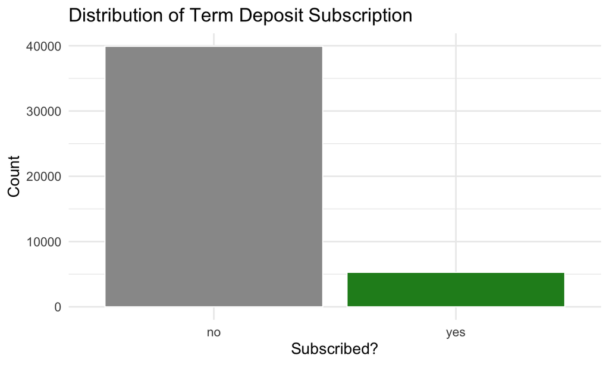

## EDA Finding 1: Contact Method Matters

- Cell phone calls perform best

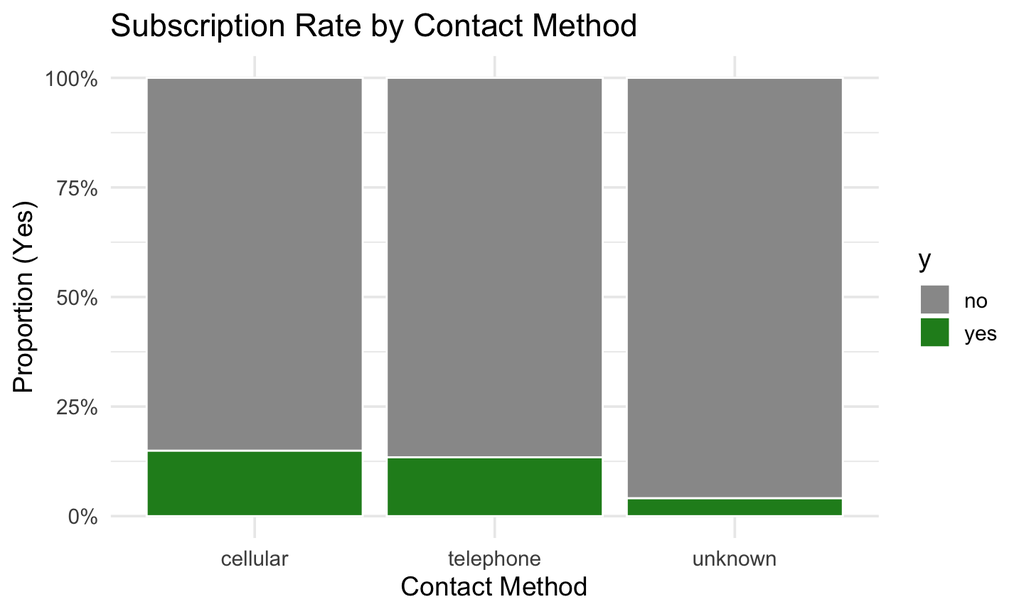

## EDA Finding 2: Previous Success Predicts Future Success

- Past success predicts new success

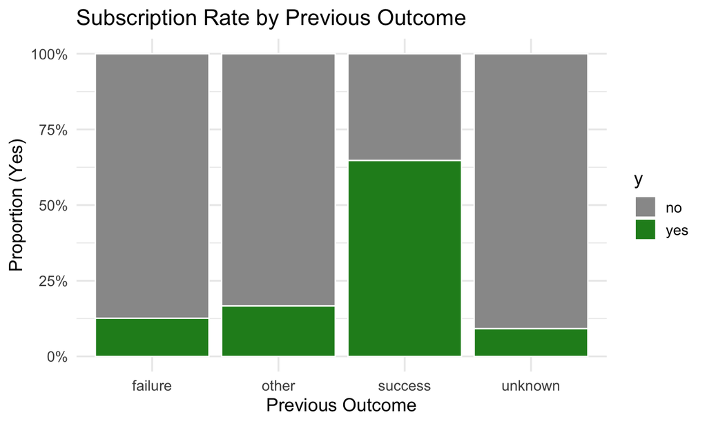

## EDA Finding 3: Too Many Calls Hurts Results

- More calls = worse results

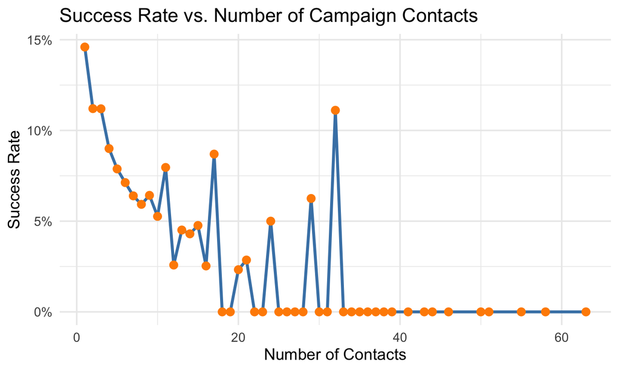

## Methodology: Data Preparation

- Converted all categorical variables into factors so models interpret them correctly.
- Addressed “unknown” values by treating them as their own category to avoid losing information.
- Created a new feature previously_contacted to properly encode pdays.
- Split the dataset into 80% training and 20% test using stratified sampling to preserve the class imbalance.
- Ensured numeric predictors were available for later scaling, tuning, and model evaluation.

## Breakdown of Categorical Variable

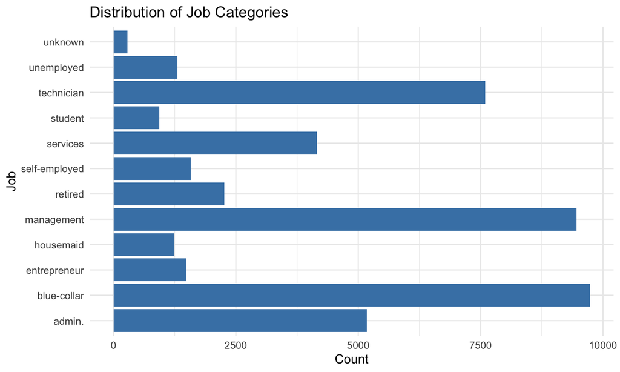

## 1. Logistic Regression Model

## Feature Selection & Linearity

- Initial feature selection was performed using **Backward Stepwise Elimination** on the full model to find the most useful set of main effects.
- Our selected formula resulted:

\(y \sim job + marital + education + balance + housing + loan + contact +\)

\(day + month + duration + campaign + previous+ poutcome\)

- Residual Plots were used to assess the linearity assumption for numeric predictors (`age`, `balance`). This led to testing a model with non-linear terms.

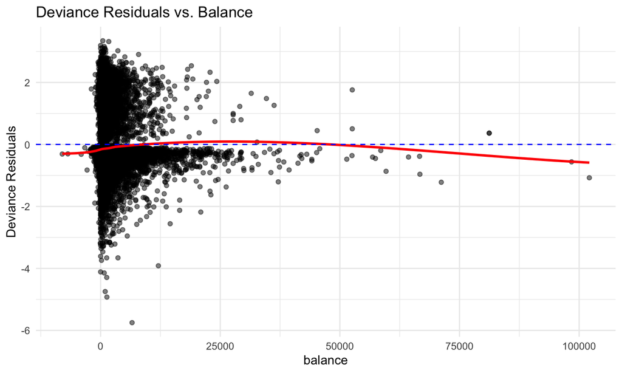

## Regularization & Tuning

- We explored Ridge and LASSO regularization as an alternative approach for feature selection.
- **5-Fold Cross-Validation** was used to select the optimal penalty parameter, \(\lambda\), which minimized the mean CV error for each regularized model.

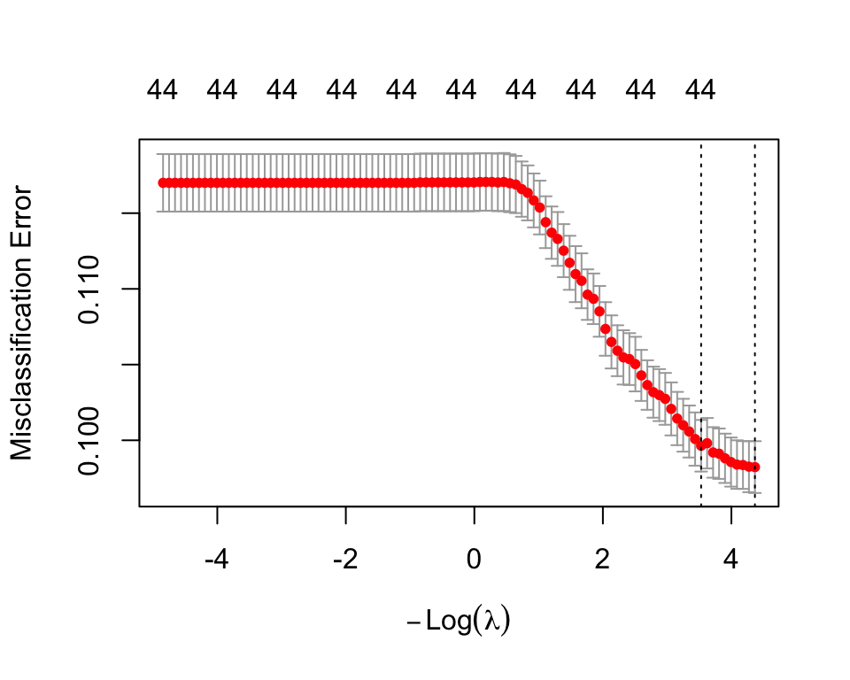

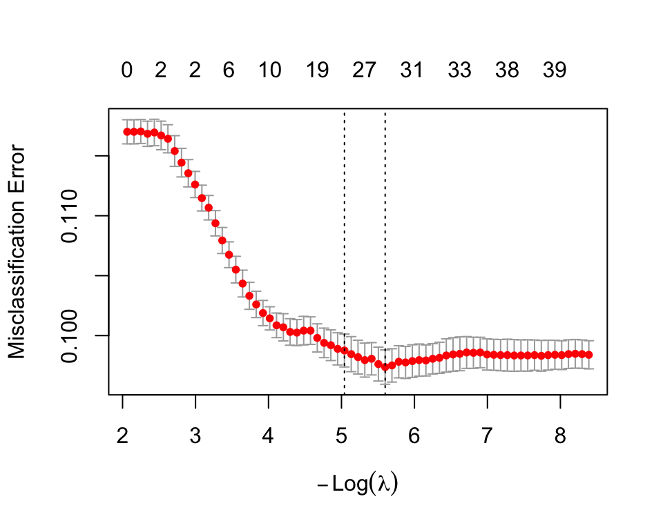

## Evaluation

- The final selected LogReg model was evaluated on the 5-fold CV error rate, along with metrics focused on the confusion matrix.
- Models performed relatively similar. We would prefer a model with higher *sensitivity* (few false negatives)

| Model | Accuracy | Sensitivity | Specificity | AUC |
| --- | --- | --- | --- | --- |
| Baseline Logit | 0.8996792 | 0.3301798 | 0.9750752 | 0.9077627 |
| Ridge Logit | 0.8982413 | 0.2800378 | 0.9800852 | 0.9080043 |
| LASSO Logit | 0.8981307 | 0.3008515 | 0.9772044 | 0.9072429 |

## 2. K-Nearest Neighbors (KNN) Model

## KNN: Feature Preparation

- **KNN** requires scaling: all numeric predictors were **standardized** (mean=0, SD=1) to prevent features with larger scales from dominating the distance calculation.
- The non-parametric nature means **no explicit feature selection** via coefficients, but the scaling step is vital for ensuring equal contribution from all dimensions.

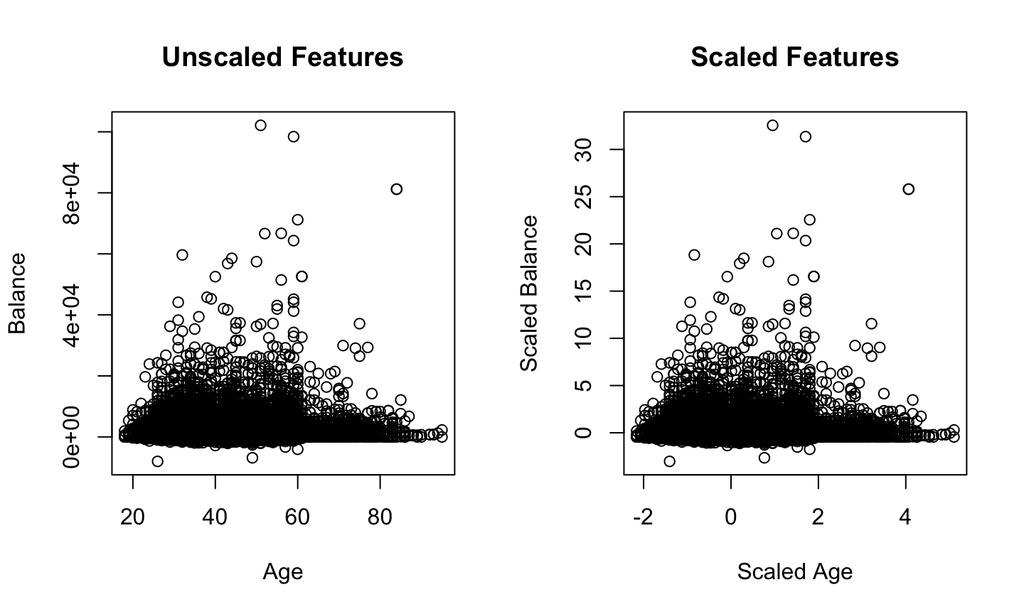

**Test Accuracy (k=5):** 88.55%

## KNN: Hyperparameter Tuning

- The sole hyperparameter, **\(k\)** (the number of neighbors), determines the model’s complexity (i.e., the bias-variance trade-off).
- **5-Fold Cross-Validation** was performed across a range of \(k\) values to find the optimal \(k\) that minimized the mean CV error.

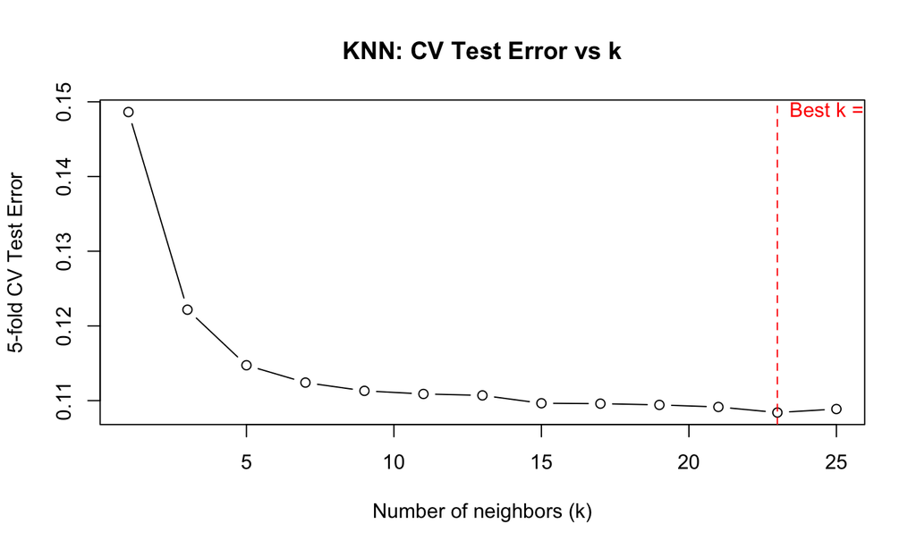

**Optimal k:** 23

## KNN: Evaluation & Test Performance

- The final KNN model (with optimal \(k\)) was applied to the **Test Set**. We evaluate performance using **AUC** and compare it to the LogReg models.
- KNN generally provides a good intermediate balance—often capturing non-linearity better than LogReg but being less computationally expensive than boosting.

| Model | AUC | Sensitivity |
| --- | --- | --- |
| KNN | 0.852 | 0.260 |
| Baseline Logit | 0.908 | 0.330 |
| Ridge | 0.908 | 0.280 |
| LASSO | 0.907 | 0.301 |

## 3. Boosting Tress Model

## Boosting: Model Formulation

- Boosting builds many small trees sequentially, each fixing errors from the previous one.
- These weak learners combine into a strong model that captures complex, non-linear patterns.
- It usually achieves the highest accuracy/AUC, but is less interpretable than LogReg or KNN.

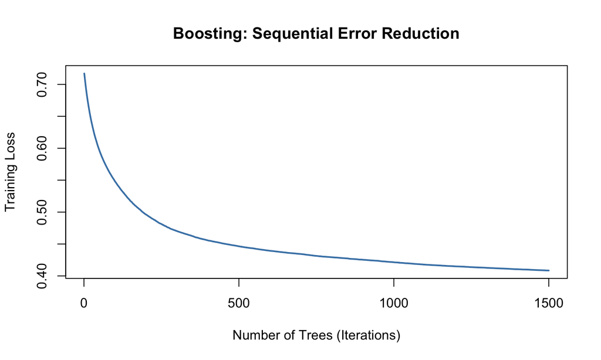

## Boosting: Hyperparameter Tuning

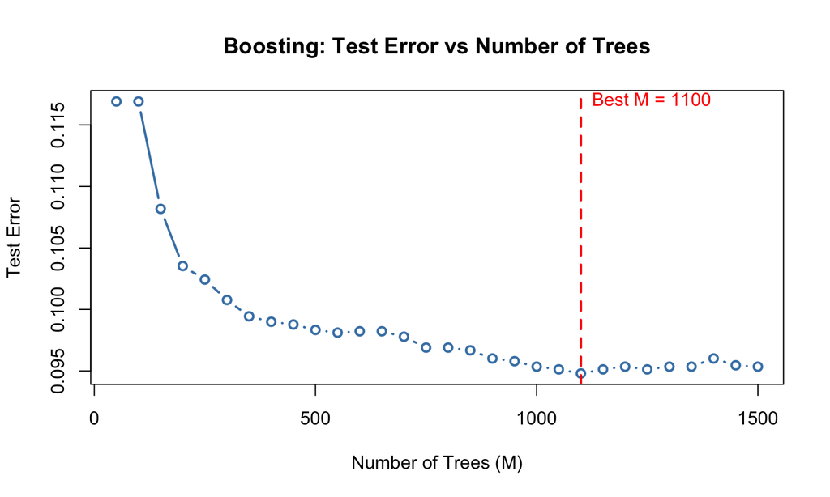

**Optimal number of trees (via test error):** 1100

## Boosting: Evaluation & Importance

- The final Boosting model achieved the highest AUC and sensitivity among all models tested.
- Variable Importance Plot shows which features influence predictions most.
- The importance rankings align with key predictors identified by Logistic Regression.

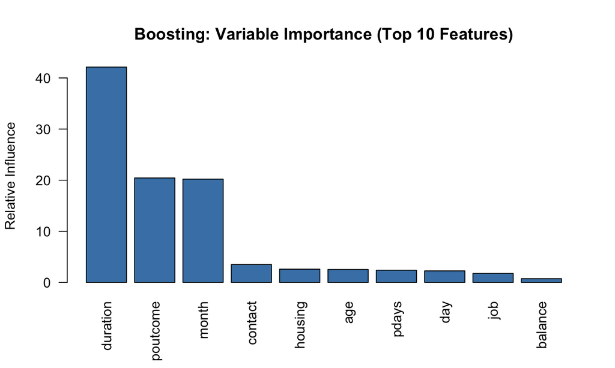

**Boosting Test AUC:** 0.927  
**Boosting Sensitivity:** 0.412  
**Boosting Accuracy:** 0.905

## Results: Comparative Evaluation

- We evaluated five models using Accuracy, Sensitivity (Recall), and AUC on the Test Set.
- **Boosting** achieved the highest overall accuracy and the highest sensitivity, meaning it identified the most true positives.
- Logistic, Ridge, and LASSO models performed very similarly in accuracy and AUC, but with lower sensitivity.
- KNN performed the worst, with the lowest AUC, indicating weak separation between classes.

## Model Performance Comparison

| Model | Accuracy | Sensitivity | AUC |
| --- | --- | --- | --- |
| Logistic | 0.900 | 0.330 | 0.908 |
| Ridge | 0.898 | 0.280 | 0.908 |
| LASSO | 0.898 | 0.301 | 0.907 |
| KNN | 0.891 | 0.260 | 0.852 |
| Boosting | 0.905 | 0.412 | 0.927 |

## ROC Curve Comparison

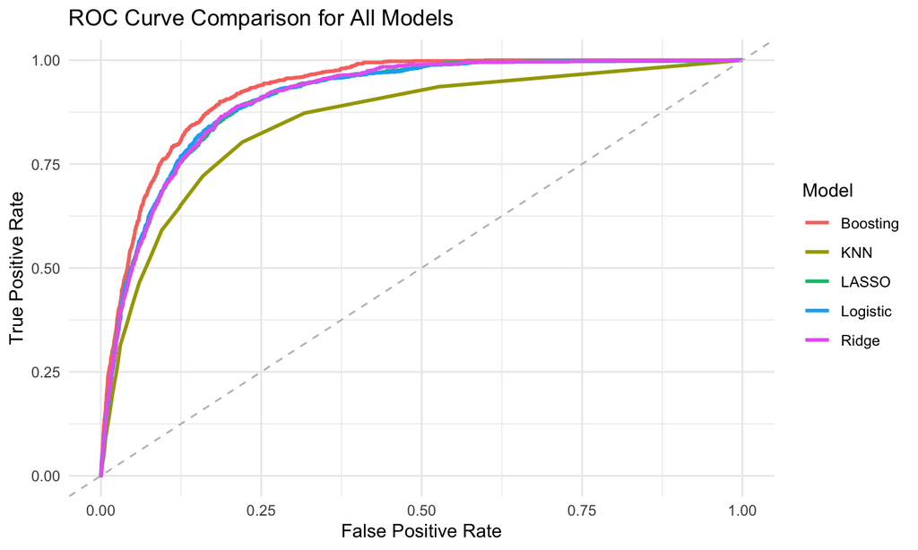

## Business Impact

- The central trade-off: Boosting is the best predictor, but the **Regularized Logistic Regression** offers the most *interpretable* and *actionable* insights for the bank.
- Sample coefficients: \(\beta_{Balance^2}\) = -23.02, \(\beta_{Housing}\) = -0.65, \(\beta_{JobStudent}\) = 4.064
- The chosen model can lead to cost savings and higher ROI for future campaigns.

## References

- UC Irvine Machine Learning Repository. Bank Marketing. https://archive.ics.uci.edu/dataset/222/bank+marketing
- Github link: https://github.com/dsci445-csu/project-6

[figure not shown]